# Lab 6

Coleman Breen

November 02, 2018

# Instructions

**Exercises:** 4 (Pg. 302); 1 (Pgs. 316-317); 1 (Pgs. 328-329); 1, 2 (Pgs. 353-354)

**Assigned:** Friday, October 26, 2018

**Due:** Friday, November 2, 2018 by 5:00 PM

**Submission:** Submit via an electronic document on Sakai. Must be submitted as a HTML file generated in RStudio. All assigned problems are chosen according to the textbook *R for Data Science*. You do not need R code to answer every question. If you answer without using R code, delete the code chunk. If the question requires R code, make sure you display R code. If the question requires a figure, make sure you display a figure. A lot of the questions can be answered in written response, but require R code and/or figures for understanding and explaining.

# Chapter 16 (Pg. 302)

## Exercise 4

Create functions that take a vector as input and return:

### a) The last value. Should you use [ or [[?

We should use [[]] because we are only interested in the last value, we don’t need to know the name.

```r
#--> Function here
function.a <- function(input){
  return(input[[length(input)]])
}

#--> Demo
x <- c(1,10,300,20,7)
function.a(x)
```

```
## [1] 7
```

### b) The elements at even numbered positions.

```r
#--> Function here
function.b <- function(input) {
  index <- c(FALSE, TRUE)
  return(input[index])
}

#--> Demo
x <- c(1,3,5,7,9)
function.b(x)
```

```
## [1] 3 7
```

### c) Every element except the last value.

```r
#--> Function here
function.c <- function(input){
  output <- input[1:length(input)-1]
  return(output)
}

#--> Demo
x <- 1:5
function.c(x)
```

```
## [1] 1 2 3 4
```

### d) Only even numbers (and no missing values).

```r
#--> Function here
function.d <- function(input) {
  index <- (input %% 2 == 0) & !(is.na(input))
  output <- input[index]
  return(output)
}

#--> Demo
x <- c(1, 1, 3, 4, 6, NaN, NaN, 10, 7, 0)
function.d(x)
```

```
## [1]  4  6 10  0
```

# Chapter 17 (Pgs. 316-317)

## Exercise 1

Write for loops to:

### a) Compute the mean of every column in mtcars

```r
#--> Load library
data(mtcars)
means <- rep(NaN, ncol(mtcars))
names(means) <- names(mtcars)

for (i in 1:ncol(mtcars)){
  means[i] <- mean(mtcars[ ,i])
}

means
```

```
##        mpg        cyl       disp         hp       drat         wt
##  20.090625   6.187500 230.721875 146.687500   3.596563   3.217250
##       qsec         vs         am       gear       carb
##  17.848750   0.437500   0.406250   3.687500   2.812500
```

### b) Determine the type of each column in nyc flights13::flights

```r
#--> Load data and compute
library(nycflights13)
data(flights)
types <- rep(NaN, ncol(flights))
names(types) <- names(flights)

for (i in names(flights)){
 types[i] <- typeof(flights[[i]])
}

types
```

```
##           year          month            day       dep_time sched_dep_time
##      "integer"      "integer"      "integer"      "integer"      "integer"
##      dep_delay       arr_time sched_arr_time      arr_delay        carrier
##       "double"      "integer"      "integer"       "double"    "character"
##         flight        tailnum         origin           dest       air_time
##      "integer"    "character"    "character"    "character"       "double"
##       distance           hour         minute      time_hour
##       "double"       "double"       "double"       "double"
```

### c) Compute the number of unique values in each column of iris

```r
#--> Load data
data(iris)
num_unique <- rep(NaN, ncol(iris))
names(num_unique) <- names(iris)

for (i in names(iris)){
  num_unique[[i]] <- length(unique(iris[[i]]))
}

num_unique
```

```
## Sepal.Length  Sepal.Width Petal.Length  Petal.Width      Species
##           35           23           43           22            3
```

### d) Generate 10 random normals for each of mu = -10, 0, 10, and 100.

```r
#--> Specify number of draws
n <- 10
mu <- c(-10, 0, 10, 100)
normals <- matrix(NaN, n, length(mu))

for (i in 1:length(mu)) {
  for (j in 1:n){
    normals[j, i] <- rnorm(1, mean = mu[i])
  }
}

normals
```

```
##             [,1]        [,2]      [,3]      [,4]
##  [1,]  -9.944756 -0.05341335  9.639318 100.33159
##  [2,]  -8.297998  2.10856215  9.878426  99.82243
##  [3,]  -9.219206 -2.47802358 11.032348 100.36032
##  [4,] -11.810242  1.52531059 10.118296 100.32589
##  [5,]  -9.588106  0.04723113 11.750508  99.38887
##  [6,]  -9.867697  1.03652524 10.044555 101.68148
##  [7,]  -7.971083 -1.68398762 10.797832 100.33035
##  [8,]  -9.810948 -0.27568271 11.567726 100.28117
##  [9,] -10.668187 -1.63487356  8.934786 100.33610
## [10,] -10.120899  0.65235018 10.191296  98.80970
```

# Chapter 17 (Pgs. 328-329)

## Exercise 1

Write code that uses one of the map functions to:

### a) Compute the mean of every column in mtcars.

```r
#--> Mean
library(purrr)
map_dbl(mtcars, mean)
```

```
##        mpg        cyl       disp         hp       drat         wt
##  20.090625   6.187500 230.721875 146.687500   3.596563   3.217250
##       qsec         vs         am       gear       carb
##  17.848750   0.437500   0.406250   3.687500   2.812500
```

### b) Determine the type of each column in flights13::flights.

```r
#--> Type
map_chr(flights, typeof)
```

```
##           year          month            day       dep_time sched_dep_time
##      "integer"      "integer"      "integer"      "integer"      "integer"
##      dep_delay       arr_time sched_arr_time      arr_delay        carrier
##       "double"      "integer"      "integer"       "double"    "character"
##         flight        tailnum         origin           dest       air_time
##      "integer"    "character"    "character"    "character"       "double"
##       distance           hour         minute      time_hour
##       "double"       "double"       "double"       "double"
```

### c) Compute the number of unique values in each column of iris.

```r
#--> Need to create an inline function
map_int(iris, function(col) length(unique(col)))
```

```
## Sepal.Length  Sepal.Width Petal.Length  Petal.Width      Species
##           35           23           43           22            3
```

### d) Generate 10 random normals for each of mu = -10, 0, 10, and 100.

```r
#--> Using the same shorthand that Wickham uses
mu <- c(-10, 0, 10, 100)
map(mu, ~ rnorm(n = 10, mean = .))
```

```
## [[1]]
##  [1]  -9.689388 -11.110829  -8.548624 -10.359259 -10.024866  -9.102165
##  [7]  -9.692533  -8.741936  -9.121292 -11.187678
##
## [[2]]
##  [1]  0.2354694 -0.5114776  1.1497544  0.1964862  1.0514499  0.1066486
##  [7] -1.9807347  0.5704419  0.9052236  0.9452469
##
## [[3]]
##  [1]  8.820269  8.643745  7.821984  9.777479  8.553401  9.900610 10.414097
##  [8]  8.353580  8.001167  9.431182
##
## [[4]]
##  [1] 100.25687 100.52591  99.16692 101.63642 100.65078  99.14784 100.26229
##  [8]  98.72188  97.39374 100.00508
```

# Chapter 18 (Pgs. 353-354)

## Exercise 1

One downside of the linear model is that it is sensitive to unusual values because the distance incorporates a squared term. Fit a linear model to the following simulated data, and visualize the results. Rerun a few times to generate different simulated datasets. What do you notice about the model?

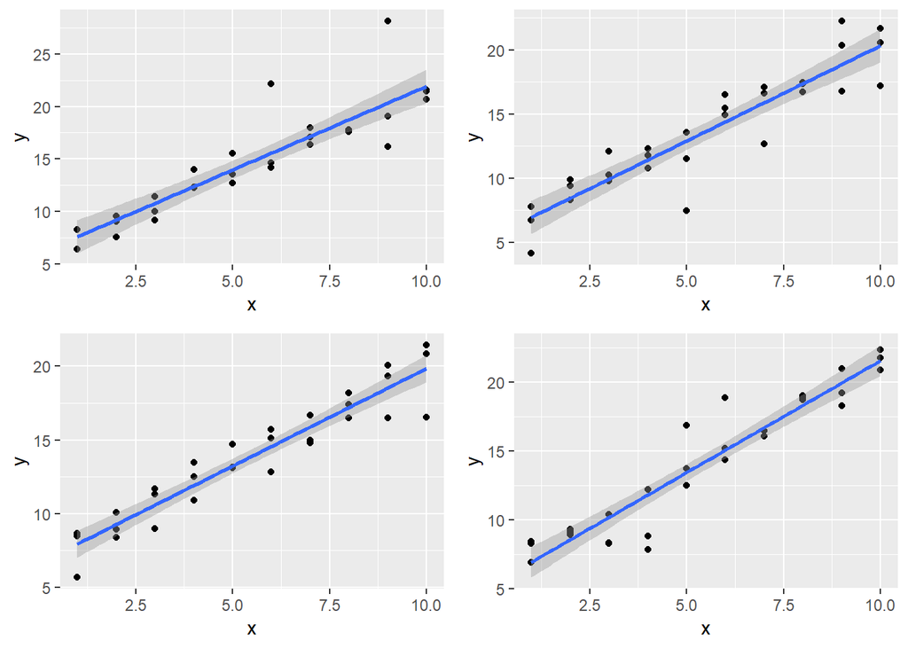

```r
#--> load library
library(tidyverse)

#--> Simulation a
sim1a <- tibble(
  x = rep(1:10, each = 3),
  y = x * 1.5 + 6 + rt(length(x), df = 2)
)

#--> Simulation b
sim1b <- tibble(
  x = rep(1:10, each = 3),
  y = x * 1.5 + 6 + rt(length(x), df = 2)
)

#--> Simulation c
sim1c <- tibble(
  x = rep(1:10, each = 3),
  y = x * 1.5 + 6 + rt(length(x), df = 2)
)

#--> Simulation d
sim1d <- tibble(
  x = rep(1:10, each = 3),
  y = x * 1.5 + 6 + rt(length(x), df = 2)
)

#--> Create four plots with lm
pa <- ggplot(sim1a, aes(x=x,y=y)) +
    geom_point() +
    stat_smooth(method="lm")
pb <- ggplot(sim1b, aes(x=x,y=y)) +
    geom_point() +
    stat_smooth(method="lm")
pc <- ggplot(sim1c, aes(x=x,y=y)) +
    geom_point() +
    stat_smooth(method="lm")
pd <- ggplot(sim1d, aes(x=x,y=y)) +
    geom_point() +
    stat_smooth(method="lm")

#--> Arrange onto one frame
library(gridExtra)
grid.arrange(grobs = list(pa, pb, pc, pd), nrow = 2)
```

As discussed in the book, linear models are sensitive to points farther away from the plane because a linear model involves squaring terms. The first time I ran these simulations, the each had very different y-intercepts (e.g. 0, 5, and 10) because a couple points pulled the linear model one way or the other.

## Exercise 2

One way to make linear models more robust is to use a different distance measure. For example, instead of root-mean-squared distance, you could use mean-absolute distance:

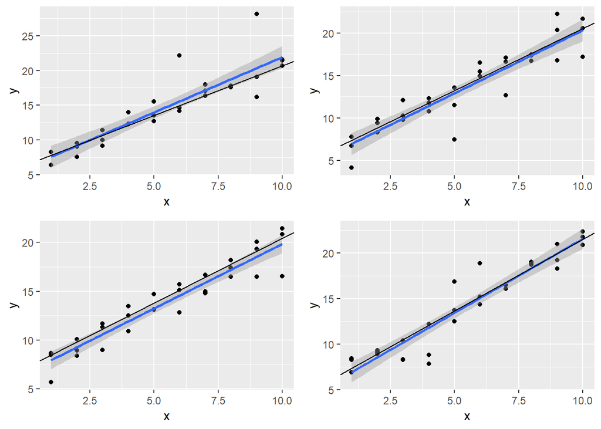

```r
#--> Data simulated before
#--> Copy function in
measure_distance <- function(mod, data) {
  diff <- data$y - make_prediction(mod, data)
  mean(abs(diff))
}

#--> My precition function
make_prediction <- function(mod, data){
  mod[1] + mod[2] * data$x
}

#--> Use optim
besta <- optim(c(0,0), measure_distance, data=sim1a)
bestb <- optim(c(0,0), measure_distance, data=sim1b)
bestc <- optim(c(0,0), measure_distance, data=sim1c)
bestd <- optim(c(0,0), measure_distance, data=sim1d)

#--> Add new models to old plots and replot
pa <- pa + geom_abline(intercept = besta$par[1], slope = besta$par[2])
pb <- pb + geom_abline(intercept = bestb$par[1], slope = bestb$par[2])
pc <- pc + geom_abline(intercept = bestc$par[1], slope = bestc$par[2])
pd <- pd + geom_abline(intercept = bestd$par[1], slope = bestd$par[2])

grid.arrange(grobs = list(pa, pb, pc, pd), nrow = 2)
```

When I look at the second method of fitting a model (in black) I see that it is less sensitive to outliers, which is what we wanted.